# STOR 320 Tutorial on Modeling IV

November 04, 2025

# Introduction

We will continue our work with daily water temperature and air temperature data observed for 31 rivers in Spain. In the preview below, `W` represents the daily maximum water temperature and `A` represents the daily maximum air temperature. The data contains almost a full year of data for each of the 31 different rivers.

```
## # A tibble: 6 × 8
##   JULIAN_DAY  YEAR     L     W     A  TIME MONTH   DAY
##        <dbl> <dbl> <dbl> <dbl> <dbl> <dbl> <dbl> <dbl>
## 1          1  2003   103  14.2  21.2     1     1     1
## 2          2  2003   103  14.4  16.8     2     1     2
## 3          3  2003   103  14.4  15.4     3     1     3
## 4          4  2003   103  10.9  10.8     4     1     4
## 5          5  2003   103  10.8  11.7     5     1     5
## 6          6  2003   103  10.7  12.4     6     1     6
```

Using the data, we seek to identify the best model for predicting the maximum water temperature given the maximum air temperature. Previously, we randomly selected 3 rivers to act as a test set. All models were evaluated based on the randomly selected test set. In this tutorial, we explore approaches that ensure that all data is used for both model training and model testing.

In this tutorial, we apply helpful functions in the `purrr`, `modelr`, and `broom` packages. See the following links for helpful articles on performing cross-validation within the tidyverse: [Link 1](https://sjspielman.github.io/bio5312_fall2017/files/kfold_supplement.pdf), [Link 2](https://drsimonj.svbtle.com/k-fold-cross-validation-with-modelr-and-broom), and [Link 3](https://www.r-bloggers.com/easy-cross-validation-in-r-with-modelr/).

# Part 1: Intelligent Use of Locations for Cross-Validation

## Chunk 1: List-Column of Data Split By Location

```r
NEST.DATA = DATA %>% group_by(L) %>% nest()
head(NEST.DATA)
```

```
## # A tibble: 6 × 2
## # Groups:   L [6]
##       L data
##   <dbl> <list>
## 1   103 <tibble [365 × 7]>
## 2   105 <tibble [366 × 7]>
## 3   107 <tibble [365 × 7]>
## 4   111 <tibble [365 × 7]>
## 5   112 <tibble [366 × 7]>
## 6   118 <tibble [366 × 7]>
```

## Chunk 2: Combining `filter()` with `unnest()` To Split Data

```r
NEST.DATA %>% filter(L==103) %>% unnest() %>% glimpse()
```

```
## Rows: 365
## Columns: 8
## Groups: L [1]
## $ L          <dbl> 103, 103, 103, 103, 103, 103, 103, 103, 103, 103, 103, 103,…
## $ JULIAN_DAY <dbl> 1, 2, 3, 4, 5, 6, 7, 8, 9, 10, 11, 12, 13, 14, 15, 16, 17, …
## $ YEAR       <dbl> 2003, 2003, 2003, 2003, 2003, 2003, 2003, 2003, 2003, 2003,…
## $ W          <dbl> 14.2, 14.4, 14.4, 10.9, 10.8, 10.7, 10.3, 10.1, 9.8, 10.5, …
## $ A          <dbl> 21.2, 16.8, 15.4, 10.8, 11.7, 12.4, 13.2, 11.8, 5.1, 3.5, 5…
## $ TIME       <dbl> 1, 2, 3, 4, 5, 6, 7, 8, 9, 10, 11, 12, 13, 14, 15, 16, 17, …
## $ MONTH      <dbl> 1, 1, 1, 1, 1, 1, 1, 1, 1, 1, 1, 1, 1, 1, 1, 1, 1, 1, 1, 1,…
## $ DAY        <dbl> 1, 2, 3, 4, 5, 6, 7, 8, 9, 10, 11, 12, 13, 14, 15, 16, 17, …
```

```r
NEST.DATA %>% filter(L!=103) %>% unnest() %>% glimpse()
```

```
## Rows: 10,972
## Columns: 8
## Groups: L [30]
## $ L          <dbl> 105, 105, 105, 105, 105, 105, 105, 105, 105, 105, 105, 105,…
## $ JULIAN_DAY <dbl> 1, 2, 3, 4, 5, 6, 7, 8, 9, 10, 11, 12, 13, 14, 15, 16, 17, …
## $ YEAR       <dbl> 2008, 2008, 2008, 2008, 2008, 2008, 2008, 2008, 2008, 2008,…
## $ W          <dbl> 7.9, 7.8, 8.7, 9.0, 9.4, 10.4, 9.9, 9.8, 10.3, NA, 9.5, 9.5…
## $ A          <dbl> 14.0, 15.0, 12.4, 14.6, 18.0, 18.2, 12.0, 14.2, 16.3, NA, 1…
## $ TIME       <dbl> 1, 2, 3, 4, 5, 6, 7, 8, 9, 10, 11, 12, 13, 14, 15, 16, 17, …
## $ MONTH      <dbl> 1, 1, 1, 1, 1, 1, 1, 1, 1, 1, 1, 1, 1, 1, 1, 1, 1, 1, 1, 1,…
## $ DAY        <dbl> 1, 2, 3, 4, 5, 6, 7, 8, 9, 10, 11, 12, 13, 14, 15, 16, 17, …
```

## Chunk 3: Fit Train Data, Predict Test Data, and Save Results

```r
DATA2=DATA
DATA2$linpred=NA

TEST = NEST.DATA %>% filter(L==103) %>% unnest()
TRAIN  = NEST.DATA %>% filter(L!=103) %>% unnest()

linmod=lm(W~A,data=TRAIN)
linmodpred=predict(linmod,newdata=TEST)

DATA2$linpred[which(DATA2$L==103)]=linmodpred
tail(DATA2)
```

```
## # A tibble: 6 × 9
##   JULIAN_DAY  YEAR     L     W     A  TIME MONTH   DAY linpred
##        <dbl> <dbl> <dbl> <dbl> <dbl> <dbl> <dbl> <dbl>   <dbl>
## 1        361  2008   920   6.3   4     361    12    26      NA
## 2        362  2008   920   6.5   8     362    12    27      NA
## 3        363  2008   920   7     8.5   363    12    28      NA
## 4        364  2008   920   7.4   6     364    12    29      NA
## 5        365  2008   920   7.8  11     365    12    30      NA
## 6        366  2008   920   8.7  11     366    12    31      NA
```

## Chunk 4: Create a Loop to Iterate Process for Each Location

```r
DATA2=DATA
DATA2$linpred=NA

for(k in unique(DATA2$L)){
  # Here we loop over 31 locations. k takes values from (103,105,107,...)
  TEST = NEST.DATA %>% filter(L==k) %>% unnest()
  TRAIN  = NEST.DATA %>% filter(L!=k) %>% unnest()

  linmod=lm(W~A,data=TRAIN)
  linmodpred=predict(linmod,newdata=TEST)

  DATA2$linpred[which(DATA2$L==k)]=linmodpred
}
```

## Chunk 5: Calcuate Cross-Validated RMSE

```r
RMSE.func=function(actual,predict){
  mse=mean((actual-predict)^2,na.rm=T)
  rmse=sqrt(mse)
  return(rmse)
}
RMSE.func(actual=DATA2$W,predict=DATA2$linpred)
```

```
## [1] 3.147084
```

# Part 2: K-Fold CV for Polynomial Model Evaluation

## Cross Validation

- One way to evaluate and compare the performance of different models

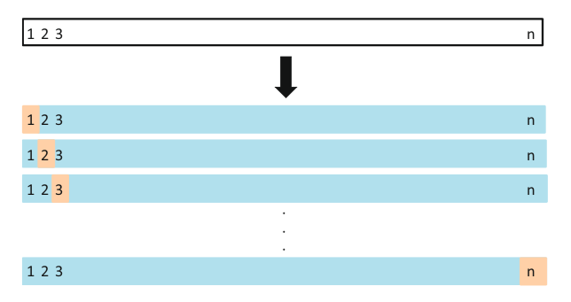

- Leave-one-out cross-validation
  - repeatedly fit the statistical learning method using training sets that contain $n - 1$ observations, and get the prediction of the excluded observation.
    $$CV_{(n)} = \frac{1}{n}\sum_{i=1}^n MSE_i$$
    where $MSE_i = (y_i-\hat{y}_i)^2$ based on $x_i$ and model fitted by $\{(x_1,y_1),...,(x_{i-1},y_{i-1}),(x_{i+1},y_{i+1}),...,(x_n,y_n)\}$.
  - there is no randomness in the training/validation set splits; performing LOOCV multiple times will always yield the same results.
  - can also be used in the classification setting by replacing $MSE_i$ with error rate $Err_i = I(y_i\neq \hat{y_i})$

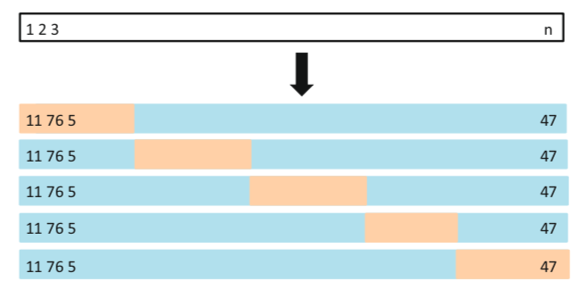

- K-fold cross-validation
  - involves randomly dividing the set of observations into k groups of approximately equal size. The first fold is treated as a validation set, and the method is fit on the remaining k-1 folds. The mean squared error, $MSE_1$, is then computed on the observations in the held-out fold. This procedure is repeated k times.
    $$CV_{(k)} = \frac{1}{k}\sum_{i=1}^k MSE_i$$

## Chunk 1: Exploratory Figures

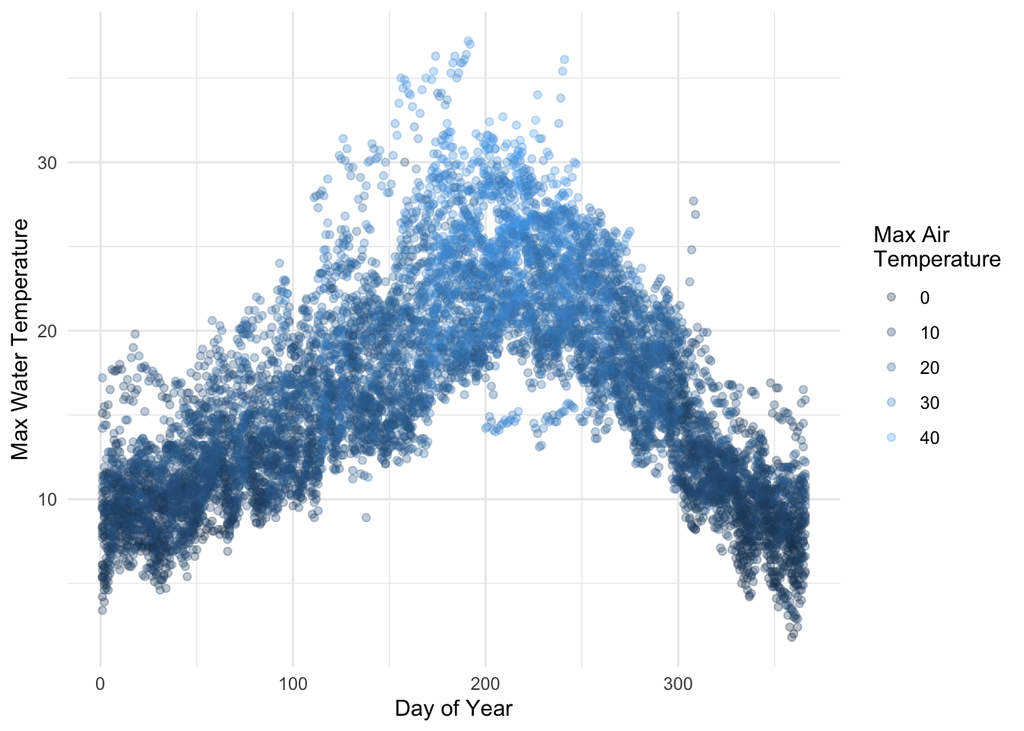

## Chunk 2: Polynomial Fitting

$$W=a+\sum_{i=1}^Ib_iA^i+\sum_{j=1}^Jc_jD^j+\varepsilon$$

```r
polymodel=lm(W~poly(A,4)+poly(JULIAN_DAY,3),data=na.omit(DATA))
tidy(polymodel)
```

```
## # A tibble: 8 × 5
##   term                 estimate std.error statistic  p.value
##   <chr>                   <dbl>     <dbl>     <dbl>    <dbl>
## 1 (Intercept)             16.2     0.0273    595.   0
## 2 poly(A, 4)1            328.      4.36       75.3  0
## 3 poly(A, 4)2             49.0     2.80       17.5  1.62e-67
## 4 poly(A, 4)3              2.85    2.78        1.02 3.06e- 1
## 5 poly(A, 4)4             -3.62    2.72       -1.33 1.84e- 1
## 6 poly(JULIAN_DAY, 3)1    46.0     2.78       16.6  8.85e-61
## 7 poly(JULIAN_DAY, 3)2  -226.      4.31      -52.5  0
## 8 poly(JULIAN_DAY, 3)3   -59.3     2.89      -20.5  8.66e-92
```

```r
glance(polymodel)
```

```
## # A tibble: 1 × 12
##   r.squared adj.r.squared sigma statistic p.value    df  logLik    AIC    BIC
##       <dbl>         <dbl> <dbl>     <dbl>   <dbl> <dbl>   <dbl>  <dbl>  <dbl>
## 1     0.797         0.797  2.71     5525.       0     7 -23804. 47626. 47691.
## # ℹ 3 more variables: deviance <dbl>, df.residual <int>, nobs <int>
```

## Chunk 3: Splitting Data for Cross-Validation

```r
DATA3=na.omit(DATA) %>% crossv_kfold(10)
DATA3
```

```
## # A tibble: 10 × 3
##    train                  test                 .id
##    <named list>           <named list>         <chr>
##  1 <resample [8,871 x 8]> <resample [986 x 8]> 01
##  2 <resample [8,871 x 8]> <resample [986 x 8]> 02
##  3 <resample [8,871 x 8]> <resample [986 x 8]> 03
##  4 <resample [8,871 x 8]> <resample [986 x 8]> 04
##  5 <resample [8,871 x 8]> <resample [986 x 8]> 05
##  6 <resample [8,871 x 8]> <resample [986 x 8]> 06
##  7 <resample [8,871 x 8]> <resample [986 x 8]> 07
##  8 <resample [8,872 x 8]> <resample [985 x 8]> 08
##  9 <resample [8,872 x 8]> <resample [985 x 8]> 09
## 10 <resample [8,872 x 8]> <resample [985 x 8]> 10
```

## Chunk 4: Fitted Models and Predictions

```r
train.model.func=function(data,i,j){
  mod=lm(W~poly(A,i)+poly(JULIAN_DAY,j),data=data)
  return(mod)
}

i=4
j=3

DATA4=DATA3 %>%
       mutate(tr.model=map(train,train.model.func,i=i,j=j))
DATA4
```

```
## # A tibble: 10 × 4
##    train                  test                 .id   tr.model
##    <named list>           <named list>         <chr> <named list>
##  1 <resample [8,871 x 8]> <resample [986 x 8]> 01    <lm>
##  2 <resample [8,871 x 8]> <resample [986 x 8]> 02    <lm>
##  3 <resample [8,871 x 8]> <resample [986 x 8]> 03    <lm>
##  4 <resample [8,871 x 8]> <resample [986 x 8]> 04    <lm>
##  5 <resample [8,871 x 8]> <resample [986 x 8]> 05    <lm>
##  6 <resample [8,871 x 8]> <resample [986 x 8]> 06    <lm>
##  7 <resample [8,871 x 8]> <resample [986 x 8]> 07    <lm>
##  8 <resample [8,872 x 8]> <resample [985 x 8]> 08    <lm>
##  9 <resample [8,872 x 8]> <resample [985 x 8]> 09    <lm>
## 10 <resample [8,872 x 8]> <resample [985 x 8]> 10    <lm>
```

## Chunk 5: Predicted Values and Cross-Validated RMSE

```r
DATA4.PREDICT = DATA4 %>%
          mutate(predict=map2(tr.model,test,~augment(.x,newdata=.y))) %>%
          select(predict) %>%
          unnest(predict)
head(DATA4.PREDICT)
```

```
## # A tibble: 6 × 10
##   JULIAN_DAY  YEAR     L     W     A  TIME MONTH   DAY .fitted .resid
##        <dbl> <dbl> <dbl> <dbl> <dbl> <dbl> <dbl> <dbl>   <dbl>  <dbl>
## 1          2  2003   103  14.4  16.8     2     1     2   10.5   3.91
## 2          6  2003   103  10.7  12.4     6     1     6    9.18  1.52
## 3         24  2003   103   9.7  14.5    24     1    24   10.5  -0.829
## 4         27  2003   103  10.1  17.2    27     1    27   11.6  -1.48
## 5         31  2003   103  11.7   8.6    31     1    31    9.06  2.64
## 6         46  2003   103  12.5   8.5    46     2    15    9.66  2.84
```

```r
RMSE.func(actual=DATA4.PREDICT$W,predict=DATA4.PREDICT$.fitted)
```

```
## [1] 2.709516
```

## Chunk 6: Select Best (i,j) Pair

```r
max_i = 10
max_j = 10
rmse_results = matrix(NA,max_i,max_j)
for(i in 1:max_i){
  for(j in 1:max_j){
    DATA4=DATA3 %>%
       mutate(tr.model=map(train,train.model.func,i=i,j=j))
    DATA4.PREDICT = DATA4 %>%
          mutate(predict=map2(test,tr.model,~augment(.y,newdata=.x))) %>%
          select(predict) %>%
          unnest(cols = c(predict))
    rmse_results[i,j] = RMSE.func(actual=DATA4.PREDICT$W,predict=DATA4.PREDICT$.fitted)
  }
}
```

```r
which(rmse_results==min(rmse_results), arr.ind = T)
```

```
##      row col
## [1,]   3  10
```

# Part 3: Exercise on Simulated Data

1. We will now perform cross-validation on a simulated data set.
1. Generate a simulated data set as follows: n=100 and p=2, the model used is
   $$Y = X - 2X^2 + \epsilon$$
   $\epsilon$ here follow standard normal distribution.

```r
set.seed(123)
x=rnorm(100)
y=x-2*x^2+rnorm (100)
sim=tibble(predictor=x,response=y)
```

2. Create a scatterplot of X against Y. Comment on what you find.

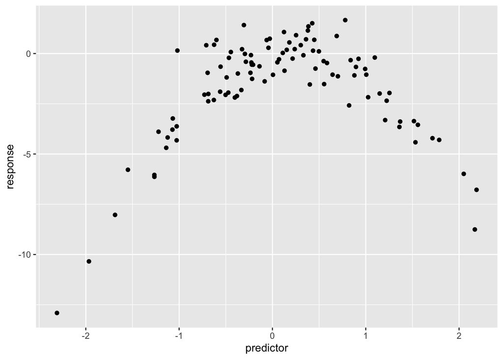

```r
ggplot(data=sim) +
  geom_point(aes(x=predictor,y=response))
```

3. Compute the 5-Fold RMSE that result from fitting the following four models:
1. $Y = \beta_0 + \beta_1X + \epsilon$
2. $Y = \beta_0 + \beta_1X + \beta_2X^2 + \epsilon$
3. $Y = \beta_0 + \beta_1X + \beta_2X^2 + \beta_3X^3 + \epsilon$
4. $Y = \beta_0 + \beta_1X + \beta_2X^2 + \beta_3X^3 + \beta_4X^4 + \epsilon$

```r
max_i = 4
rmse_ex = rep(NA,max_i)
train.model.func2 = function(data,i){
  mod=lm(response~poly(predictor,i),data=data)
  return(mod)
}
for(i in 1:max_i){
  sim_final = sim %>%
    crossv_kfold(k=5) %>%
    mutate(tr.model=map(train,train.model.func2,i=i)) %>%
    mutate(predict=map2(test, tr.model, ~augment(.y,newdata=.x))) %>%
    select(predict) %>%
    unnest(cols = c(predict))
  rmse_ex[i] = RMSE.func(actual=sim_final$response,predict=sim_final$.fitted)
}
```

Check which model has the smallest RMSE:

```r
rmse_ex
```

```
## [1] 2.6635481 0.9874265 1.0107882 0.9895247
```

4. Which of the models in (c) had the smallest RMSE? Is this what you expected? Explain your answer.